# taxi_wa

## Analisi dei viaggi Taxi per la cità di Washington

### Washington City Center

Il dataset contine tutte le informazioni sui viaggi effettuati anche quelli svolti da società private.

```python
from geopy.geocoders import Nominatim
import pandas as pd
import geopandas as gpd
import datetime
from random import randint
import folium
import json
```

```python
dataset = pd.read_csv('./data/taxi_month4_fixed.csv', sep=',', error_bad_lines=False, index_col=False)
dataset.head()
```

|  | OBJECTID | TRIPTYPE | PROVIDERNAME | FAREAMOUNT | GRATUITYAMOUNT | SURCHARGEAMOUNT | EXTRAFAREAMOUNT | TOLLAMOUNT | TOTALAMOUNT | PAYMENTTYPE | ... | DURATION | ORIGIN_BLOCK_LATITUDE | ORIGIN_BLOCK_LONGITUDE | ORIGIN_BLOCKNAME | DESTINATION_BLOCK_LATITUDE | DESTINATION_BLOCK_LONGITUDE | DESTINATION_BLOCKNAME | AIRPORT | ORIGINDATETIME_TR | DESTINATIONDATETIME_TR |
| --- | --- | --- | --- | --- | --- | --- | --- | --- | --- | --- | --- | --- | --- | --- | --- | --- | --- | --- | --- | --- | --- |
| 0 | 50137831 | Ordinal | UVC | 7.84 | 2.0 | 0.25 | 0.0 | 0.0 | 10.09 | 1 | ... | 521 | 38.898314 | -77.028849 | 1200 - 1299 BLOCK OF G STREET NW | 38.917000 | -77.030786 | 1300 - 1399 BLOCK OF U STREET NW | N | 2019-04-01 16:00:00 | 04/01/2019 16:00 |
| 1 | 50137832 | Ordinal | UVC | 5.95 | 3.0 | 0.25 | 0.0 | 0.0 | 9.20 | 1 | ... | 322 | 38.910017 | -77.031953 | 1500 - 1520 BLOCK OF 14TH STREET NW | 38.914085 | -77.018411 | 432 - 499 BLOCK OF S STREET NW | N | 2019-04-01 16:00:00 | 04/01/2019 16:00 |
| 2 | 50137833 | Ordinal | Capitol Cab | 6.76 | 0.0 | 0.25 | 1.0 | 0.0 | 8.01 | 1 | ... | 448 | 38.901344 | -77.038985 | 1626 - 1699 BLOCK OF I STREET NW | 38.897344 | -77.024969 | 900 - 999 BLOCK OF F STREET NW | N | 2019-04-01 16:00:00 | 04/01/2019 16:00 |
| 3 | 50137834 | Ordinal | UVC | 4.60 | 2.0 | 0.25 | 0.0 | 0.0 | 6.85 | 1 | ... | 188 | 38.894784 | -77.011557 | 36 - 99 BLOCK OF D STREET NW | 38.892576 | -77.019242 | 510 - 599 BLOCK OF PENNSYLVANIA AVENUE NW | N | 2019-04-01 16:00:00 | 04/01/2019 16:00 |
| 4 | 50137835 | Ordinal | UVC | 15.94 | 3.0 | 0.25 | 0.0 | 0.0 | 19.19 | 1 | ... | 1377 | 38.901812 | -77.020906 | 600 - 699 BLOCK OF MASSACHUSETTS AVENUE NW | 38.912936 | -77.076042 | 3951 - 3959 BLOCK OF GEORGETOWN COURT NW | N | 2019-04-01 16:00:00 | 04/01/2019 16:00 |

5 rows × 27 columns

### Dataset preprocessing

- E' neccessario controllare che non vi siano dati nulli.
- Eliminazione dei dati non neccessari

```python
dataset.isnull().sum()
```

```
OBJECTID                        0
TRIPTYPE                        0
PROVIDERNAME                    0
FAREAMOUNT                      0
GRATUITYAMOUNT                  0
SURCHARGEAMOUNT                 0
EXTRAFAREAMOUNT                 0
TOLLAMOUNT                      0
TOTALAMOUNT                     0
PAYMENTTYPE                     0
ORIGINCITY                      0
ORIGINSTATE                     0
ORIGINZIP                      14
DESTINATIONCITY                 0
DESTINATIONSTATE                0
DESTINATIONZIP                 14
MILEAGE                         0
DURATION                        0
ORIGIN_BLOCK_LATITUDE           0
ORIGIN_BLOCK_LONGITUDE          0
ORIGIN_BLOCKNAME                0
DESTINATION_BLOCK_LATITUDE      0
DESTINATION_BLOCK_LONGITUDE     0
DESTINATION_BLOCKNAME           0
AIRPORT                         0
ORIGINDATETIME_TR               0
DESTINATIONDATETIME_TR          0
dtype: int64
```

```python
try:
    dataset = dataset.dropna(axis=0, how='any')
    dataset = dataset.drop('OBJECTID', 1)
    dataset = dataset.drop('TRIPTYPE', 1)
    dataset = dataset.drop('PROVIDERNAME', 1)
    dataset = dataset.drop('FAREAMOUNT', 1)
    dataset = dataset.drop('GRATUITYAMOUNT', 1)
    dataset = dataset.drop('SURCHARGEAMOUNT', 1)
    dataset = dataset.drop('EXTRAFAREAMOUNT', 1)
    dataset = dataset.drop('TOLLAMOUNT', 1)
    dataset = dataset.drop('PAYMENTTYPE', 1)

except:
    print('Errore nella cancellazione delle colonne, o già eliminate.')
```

```python
dataset.head()
```

|  | TOTALAMOUNT | ORIGINCITY | ORIGINSTATE | ORIGINZIP | DESTINATIONCITY | DESTINATIONSTATE | DESTINATIONZIP | MILEAGE | DURATION | ORIGIN_BLOCK_LATITUDE | ORIGIN_BLOCK_LONGITUDE | ORIGIN_BLOCKNAME | DESTINATION_BLOCK_LATITUDE | DESTINATION_BLOCK_LONGITUDE | DESTINATION_BLOCKNAME | AIRPORT | ORIGINDATETIME_TR | DESTINATIONDATETIME_TR |
| --- | --- | --- | --- | --- | --- | --- | --- | --- | --- | --- | --- | --- | --- | --- | --- | --- | --- | --- |
| 0 | 10.09 | Washington | DC | 20009.0 | Washington | DC | 20009.0 | 1.45 | 521 | 38.898314 | -77.028849 | 1200 - 1299 BLOCK OF G STREET NW | 38.917000 | -77.030786 | 1300 - 1399 BLOCK OF U STREET NW | N | 2019-04-01 16:00:00 | 04/01/2019 16:00 |
| 1 | 9.20 | Washington | DC | 20001.0 | Washington | DC | 20001.0 | 1.00 | 322 | 38.910017 | -77.031953 | 1500 - 1520 BLOCK OF 14TH STREET NW | 38.914085 | -77.018411 | 432 - 499 BLOCK OF S STREET NW | N | 2019-04-01 16:00:00 | 04/01/2019 16:00 |
| 2 | 8.01 | Washington | DC | 20004.0 | Washington | DC | 20004.0 | 1.11 | 448 | 38.901344 | -77.038985 | 1626 - 1699 BLOCK OF I STREET NW | 38.897344 | -77.024969 | 900 - 999 BLOCK OF F STREET NW | N | 2019-04-01 16:00:00 | 04/01/2019 16:00 |
| 3 | 6.85 | Washington | DC | 20001.0 | Washington | DC | 20001.0 | 0.59 | 188 | 38.894784 | -77.011557 | 36 - 99 BLOCK OF D STREET NW | 38.892576 | -77.019242 | 510 - 599 BLOCK OF PENNSYLVANIA AVENUE NW | N | 2019-04-01 16:00:00 | 04/01/2019 16:00 |
| 4 | 19.19 | Washington | DC | 20057.0 | Washington | DC | 20057.0 | 3.89 | 1377 | 38.901812 | -77.020906 | 600 - 699 BLOCK OF MASSACHUSETTS AVENUE NW | 38.912936 | -77.076042 | 3951 - 3959 BLOCK OF GEORGETOWN COURT NW | N | 2019-04-01 16:00:00 | 04/01/2019 16:00 |

#### Plot dei valori del dataset

Grazie al grafico è possibile valutare valori fuori scala che andrebbero a contaminare il dataset. Viene definita la funzione per plottare tutto il dataset in scala normale e logaritmica.

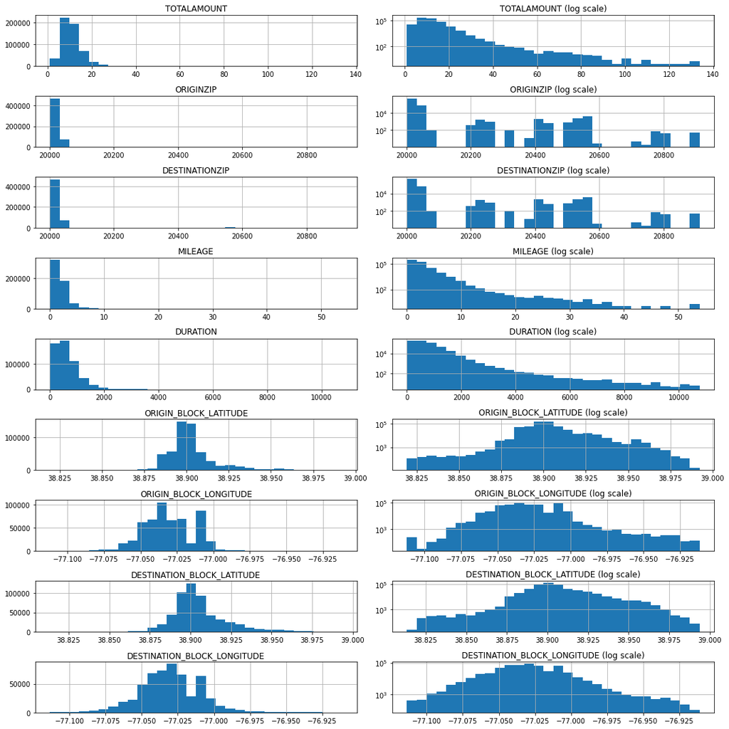

```python
import matplotlib.pyplot as plt
import numpy as np
def plot_current_graph(dataset,plot_row):
    fig, axes = plt.subplots(nrows=plot_row, ncols=2, figsize=(15,15))

    i = 1
    for col in dataset.columns:
        if dataset[col].dtype == np.float64 or dataset[col].dtype == np.int64:
            ax = plt.subplot(plot_row, 2, i)
            dataset[col].hist(bins=30)
            ax.set_title(col)
            i += 1
            ax = plt.subplot(plot_row, 2, i)
            dataset[col].hist(bins=30)
            ax.set_title(col+" (log scale)")
            ax.set_yscale('log')
            i += 1

    fig.tight_layout()
    plt.show()
plot_current_graph(dataset,9)
```

#### Elimininazione dei valori non accettabili

- Viaggi al di fuori della città di Washington
- Lunghezza viaggio massima superiore a 3h (60 *60* 3 sec)
- Viaggi superiori alle 100 miglia
- ecc..

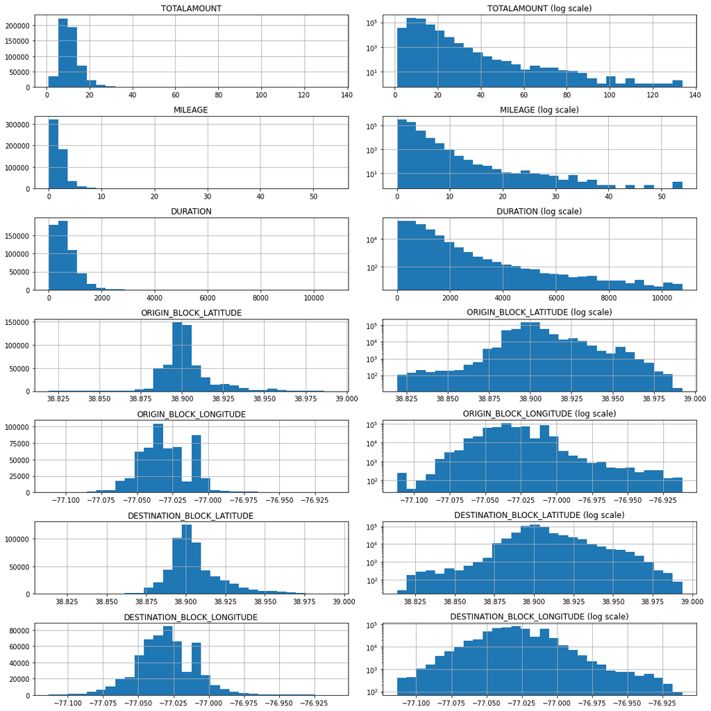

```python
#durata
dataset = dataset[dataset['DURATION'] <= 60*60*3]
dataset = dataset[dataset['DURATION'] >=0]
#totale
dataset = dataset[dataset['TOTALAMOUNT'] <= 150]
dataset = dataset[dataset['TOTALAMOUNT'] > 0]
#citta'
dataset = dataset[dataset['ORIGINCITY'] == 'Washington']
dataset = dataset[dataset['ORIGINCITY'] == 'Washington']
dataset = dataset[dataset['MILEAGE'] <= 100]
dataset = dataset[dataset['AIRPORT'] == 'N']
dataset = dataset[dataset['DESTINATIONZIP'] != '-----']
dataset = dataset[dataset['ORIGINZIP'] != '-----']
dataset['DESTINATIONZIP'] = pd.to_numeric(dataset['DESTINATIONZIP'],downcast='integer')
dataset['ORIGINZIP'] = pd.to_numeric(dataset['ORIGINZIP'],downcast='integer')

dataset = dataset[dataset['DESTINATIONZIP'] >= 20000]
dataset = dataset[dataset['ORIGINZIP'] >= 20000]
plot_current_graph(dataset,7)
```

#### Trasformo in forma standard

Per questione di uniformità si è scelto di unire i vari dataset sotto lo stesso fattore comune ossia lo Zip code o codice di avviamento postale. Il dataset presenta difformità nel campo *'DESTINATIONDATETIME_TR'*, risulta quindi neccessario modificare il tempo di arrivo in base alla durata del viaggio e all'orario di partenza.

```python
import datetime
dataset['ORIGINDATETIME_TR'] = pd.to_datetime(dataset['ORIGINDATETIME_TR'])
dataset['DURATION'] = pd.to_timedelta(dataset['DURATION'],'s')
dataset['DESTINATIONDATETIME_TR'] = dataset['ORIGINDATETIME_TR'] + dataset['DURATION']

dataset.head()
```

|  | TOTALAMOUNT | ORIGINCITY | ORIGINSTATE | ORIGINZIP | DESTINATIONCITY | DESTINATIONSTATE | DESTINATIONZIP | MILEAGE | DURATION | ORIGIN_BLOCK_LATITUDE | ORIGIN_BLOCK_LONGITUDE | ORIGIN_BLOCKNAME | DESTINATION_BLOCK_LATITUDE | DESTINATION_BLOCK_LONGITUDE | DESTINATION_BLOCKNAME | AIRPORT | ORIGINDATETIME_TR | DESTINATIONDATETIME_TR |
| --- | --- | --- | --- | --- | --- | --- | --- | --- | --- | --- | --- | --- | --- | --- | --- | --- | --- | --- |
| 0 | 10.09 | Washington | DC | 20009 | Washington | DC | 20009 | 1.45 | 0 days 00:08:41 | 38.898314 | -77.028849 | 1200 - 1299 BLOCK OF G STREET NW | 38.917000 | -77.030786 | 1300 - 1399 BLOCK OF U STREET NW | N | 2019-04-01 16:00:00 | 2019-04-01 16:08:41 |
| 1 | 9.20 | Washington | DC | 20001 | Washington | DC | 20001 | 1.00 | 0 days 00:05:22 | 38.910017 | -77.031953 | 1500 - 1520 BLOCK OF 14TH STREET NW | 38.914085 | -77.018411 | 432 - 499 BLOCK OF S STREET NW | N | 2019-04-01 16:00:00 | 2019-04-01 16:05:22 |
| 2 | 8.01 | Washington | DC | 20004 | Washington | DC | 20004 | 1.11 | 0 days 00:07:28 | 38.901344 | -77.038985 | 1626 - 1699 BLOCK OF I STREET NW | 38.897344 | -77.024969 | 900 - 999 BLOCK OF F STREET NW | N | 2019-04-01 16:00:00 | 2019-04-01 16:07:28 |
| 3 | 6.85 | Washington | DC | 20001 | Washington | DC | 20001 | 0.59 | 0 days 00:03:08 | 38.894784 | -77.011557 | 36 - 99 BLOCK OF D STREET NW | 38.892576 | -77.019242 | 510 - 599 BLOCK OF PENNSYLVANIA AVENUE NW | N | 2019-04-01 16:00:00 | 2019-04-01 16:03:08 |
| 4 | 19.19 | Washington | DC | 20057 | Washington | DC | 20057 | 3.89 | 0 days 00:22:57 | 38.901812 | -77.020906 | 600 - 699 BLOCK OF MASSACHUSETTS AVENUE NW | 38.912936 | -77.076042 | 3951 - 3959 BLOCK OF GEORGETOWN COURT NW | N | 2019-04-01 16:00:00 | 2019-04-01 16:22:57 |

```python
fixed_dataset = dataset[['ORIGINZIP', 'ORIGINDATETIME_TR', 'DESTINATIONZIP', 'DESTINATIONDATETIME_TR']]

fixed_dataset=fixed_dataset.rename(columns={'ORIGINZIP':'originZip',
                                            'ORIGINDATETIME_TR':'start_time',
                                            'DESTINATIONZIP':'destinationZip',
                                            'DESTINATIONDATETIME_TR':'end_time'
                                           })
fixed_dataset
```

|  | originZip | start_time | destinationZip | end_time |
| --- | --- | --- | --- | --- |
| 0 | 20009 | 2019-04-01 16:00:00 | 20009 | 2019-04-01 16:08:41 |
| 1 | 20001 | 2019-04-01 16:00:00 | 20001 | 2019-04-01 16:05:22 |
| 2 | 20004 | 2019-04-01 16:00:00 | 20004 | 2019-04-01 16:07:28 |
| 3 | 20001 | 2019-04-01 16:00:00 | 20001 | 2019-04-01 16:03:08 |
| 4 | 20057 | 2019-04-01 16:00:00 | 20057 | 2019-04-01 16:22:57 |
| ... | ... | ... | ... | ... |
| 554124 | 20024 | 2019-04-16 15:00:00 | 20024 | 2019-04-16 15:00:12 |
| 554125 | 20006 | 2019-04-17 16:00:00 | 20006 | 2019-04-17 16:00:21 |
| 554126 | 20005 | 2019-04-17 17:00:00 | 20005 | 2019-04-17 17:00:09 |
| 554127 | 20002 | 2019-04-20 18:00:00 | 20002 | 2019-04-20 18:00:07 |
| 554128 | 20037 | 2019-04-21 10:00:00 | 20037 | 2019-04-21 10:00:07 |

554115 rows × 4 columns

```python
dataset=fixed_dataset
dataset.isnull().sum()
```

```
originZip         0
start_time        0
destinationZip    0
end_time          0
dtype: int64
```

#### Analisi flusso in ingresso uscita per ogni area

Per l'analisi del flusso la giornata viene divisa in segmenti da 30 minuti. E' necessario passare timestamp a segmento: 2017-07-01 00:00:07 -> 2017-07-01 00:00:00 Ottengo il dataset con:

- Zip partenza
- Segmento orario partenza
- Zip arrivo
- Segmento orario arrivo

```python
def ottini_segmento(dataset):
    if dataset.minute < 30:
        minute = "%02d" % 0
    else:
        minute = "%02d" % 30
    return "{}-{}-{} {}:{}".format(dataset.year, dataset.month, dataset.day, dataset.hour, minute)
dataset['start_seg'] = [ottini_segmento(dataset) for dataset in dataset['start_time']]
dataset['stop_seg'] = [ottini_segmento(dataset) for dataset in dataset['end_time']]
```

#### Flusso uscita/entrata raggruppato

Raggruppo in base allo zip code, vedo numero di ingressi e uscite

```python
flusso_ingresso=dataset[['originZip', 'start_seg']].groupby(['originZip', 'start_seg']).size().reset_index(name='counts').rename(columns={'originZip':'zipCode','start_seg':'time', 'counts':'n_ingressi'})
flusso_uscita=dataset[['destinationZip', 'stop_seg']].groupby(['destinationZip', 'stop_seg']).size().reset_index(name='counts').rename(columns={'destinationZip':'zipCode','stop_seg':'time', 'counts':'n_uscite'})
flusso_uscita
```

|  | zipCode | time | n_uscite |
| --- | --- | --- | --- |
| 0 | 20001 | 2019-4-1 0:00 | 96 |
| 1 | 20001 | 2019-4-1 0:30 | 1 |
| 2 | 20001 | 2019-4-1 10:00 | 13 |
| 3 | 20001 | 2019-4-1 10:30 | 1 |
| 4 | 20001 | 2019-4-1 11:00 | 50 |
| ... | ... | ... | ... |
| 25040 | 20912 | 2019-4-7 2:00 | 1 |
| 25041 | 20912 | 2019-4-7 3:00 | 2 |
| 25042 | 20912 | 2019-4-7 6:00 | 1 |
| 25043 | 20912 | 2019-4-8 13:00 | 1 |
| 25044 | 20912 | 2019-4-8 3:00 | 1 |

25045 rows × 3 columns

### Merge dei dati

Unisco dati sotto lo stesso zip code e orario. Se non ci sono ingressi o uscite viene prodotto un NaN -> sostitusico con 0

```python
flusso_in_out_zipcode = pd.merge(flusso_ingresso, flusso_uscita, on=['zipCode', 'time'], how='outer')
flusso_in_out_zipcode['n_ingressi'] = flusso_in_out_zipcode['n_ingressi'].replace(np.nan, 0)
flusso_in_out_zipcode['n_uscite'] = flusso_in_out_zipcode['n_uscite'].replace(np.nan, 0)

flusso_in_out_zipcode.head()
```

|  | zipCode | time | n_ingressi | n_uscite |
| --- | --- | --- | --- | --- |
| 0 | 20001 | 2019-4-1 0:00 | 97.0 | 96.0 |
| 1 | 20001 | 2019-4-1 10:00 | 14.0 | 13.0 |
| 2 | 20001 | 2019-4-1 11:00 | 51.0 | 50.0 |
| 3 | 20001 | 2019-4-1 12:00 | 105.0 | 103.0 |
| 4 | 20001 | 2019-4-1 13:00 | 105.0 | 104.0 |

# Analisi dei risultati

### Tre zone più popolari secondo il flusso di ingresso/uscita medio

```python
media_ingresso=flusso_in_out_zipcode[['zipCode','n_ingressi']].groupby(['zipCode']).mean().sort_values(by='n_ingressi',ascending=False)
media_uscita=flusso_in_out_zipcode[['zipCode','n_uscite']].groupby(['zipCode']).mean().sort_values(by='n_uscite',ascending=False)
top_zone_ingresso = list(media_ingresso.head(3).index)
top_zone_uscita = list(media_uscita.head(3).index)
print('Le zone con media di ingresso più alta sono ' + str(top_zone_ingresso))
print('Le zone con media di uscita più alta sono ' + str(top_zone_uscita))
```

```
Le zone con media di ingresso più alta sono [20001, 20005, 20002]
Le zone con media di uscita più alta sono [20001, 20005, 20002]
```

### Grafico del flusso di ingresso uscita per un perido di tempo di una zona

Seleziono in questo caso una delle zone piu' frequentate ossia quella identificata dallo zip code *20001*.

Seleziono la zona:

```python
analisi_zona = flusso_in_out_zipcode[flusso_in_out_zipcode['zipCode'] == 20001].sort_values(by='time')
analisi_zona = analisi_zona.sort_values(by='time')
analisi_zona.head()
```

|  | zipCode | time | n_ingressi | n_uscite |
| --- | --- | --- | --- | --- |
| 0 | 20001 | 2019-4-1 0:00 | 97.0 | 96.0 |
| 20541 | 20001 | 2019-4-1 0:30 | 0.0 | 1.0 |
| 1 | 20001 | 2019-4-1 10:00 | 14.0 | 13.0 |
| 20542 | 20001 | 2019-4-1 10:30 | 0.0 | 1.0 |
| 2 | 20001 | 2019-4-1 11:00 | 51.0 | 50.0 |

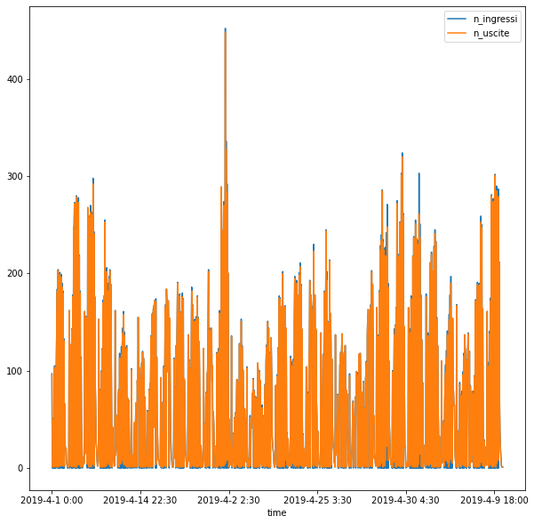

```python
analisi_zona.plot(x='time', y=['n_ingressi', 'n_uscite'], kind='line', figsize=(10,10))
plt.show()
```

### Visualizzazione zona con più richiesta per una determinata ora

#### Creazione mappa statica stile heatmap dove si evidenziano le zone con più richieste.

```python
with open('./data/mygeodata_merged.json', 'r') as file_zip:
        zip_wa = json.load(file_zip)

list_wa_zip_code=[]
for zip_code in zip_wa['features']:
    list_wa_zip_code.append(zip_code['properties']['ZIPCODE'])
list_wa_zip_code_df = pd.DataFrame(list_wa_zip_code, columns=['zipCode'])
list_wa_zip_code_df
def create_map_zipCode(df,column):
    global list_wa_zip_code_df
    tmp=pd.merge(df, list_wa_zip_code_df, on=['zipCode'], how='outer')
    tmp=tmp.replace(np.nan,0)
    m = folium.Map(location=[38.8951, -77.0364],
               zoom_start=12)
    folium.Choropleth(
        geo_data=zip_wa,
        data=flusso_heat_map,
        columns=['zipCode', column],
        key_on='feature.properties.ZIPCODE',
        fill_color='YlOrRd',
        fill_opacity=0.8,
        line_opacity=0.1,
    ).add_to(m)
    #print('end')
    return m
```

```python
flusso_heat_map = flusso_in_out_zipcode[flusso_in_out_zipcode['time'] == '2019-4-12 13:00']
flusso_heat_map.head()
```

|  | zipCode | time | n_ingressi | n_uscite |
| --- | --- | --- | --- | --- |
| 75 | 20001 | 2019-4-12 13:00 | 100.0 | 99.0 |
| 786 | 20002 | 2019-4-12 13:00 | 145.0 | 144.0 |
| 1501 | 20003 | 2019-4-12 13:00 | 42.0 | 42.0 |
| 2152 | 20004 | 2019-4-12 13:00 | 99.0 | 99.0 |
| 2806 | 20005 | 2019-4-12 13:00 | 106.0 | 106.0 |

```python
create_map_zipCode(flusso_heat_map,'n_uscite')
```

Make this Notebook Trusted to load map: File -> Trust Notebook

[interactive chart not shown]